# BIOST 537 final project

Yuhan Wang

3/5/2021

**1. What are the main characteristics of the estimated distribution of disease-free survival time in patients enrolled in this study?**

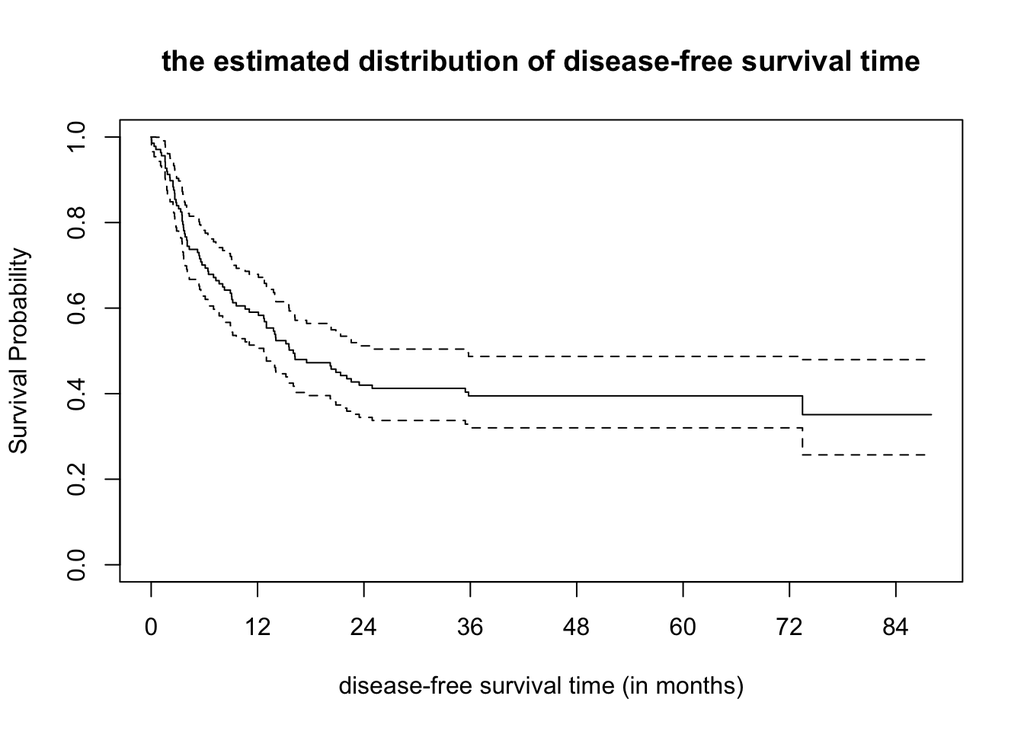

```r
km.data<-survfit(Surv(tdfs/30,deltadfs)~1,data=data)
plot(km.data,main="the estimated distribution of disease-free survival time",xlab = "disease-free survival time (in months)",ylab="Survival Probability",xaxt="n")
axis(side=1, at=seq(0,88,by=12))
```

The estimated median disease-free survival time is 16 months (95% CI: 13-35). The estimated distrubtion of disease-free survival time sharply decreased from 0 -24 months, flattened out at 24 months and remained roughly constant until the end of study, with a slight decrease at 36 months and 72 months.

**2. How do patients in different disease groups or in different FAB classifications compare to each other with respect to other available baseline measurements?**

```r
data$male<-factor(data$male,levels=c(0,1),labels=c("Female","Male"))
data$donormale<-factor(data$donormale,levels=c(0,1),labels=c("Female","Male"))
data$cmv<-factor(data$cmv,levels=c(0,1),labels=c("Negative","Positive"))
data$donorcmv<-factor(data$donorcmv,levels=c(0,1),labels=c("Negative","Positive"))
data$mtx<-factor(data$mtx,levels=c(0,1),labels=c("No","Yes"))
data$fab<-factor(data$fab,levels=c(1,0),labels=c("FAB grade 4 or 5 and AML","Other"))

data$disgroup<-factor(data$disgroup,levels=c(1,2,3),labels = c("ALL","AML low risk","AML high risk"))
label(data$male)<-"Patient sex"
label(data$age)<-"Patient age (years)"
label(data$donormale)<-"Donor sex"
label(data$donorage)<-"Donor age (years)"
label(data$cmv)<-"Patient CMV status"
label(data$donorcmv)<-"Donor CMV status"
label(data$waittime)<-"Waiting time until transplant (days)"
label(data$mtx)<-"Prophylactic use of methotrexate "


table1(~age+male+cmv+donorage+donormale+donorcmv+waittime+mtx|disgroup,data=data)
```

|  | ALL (N=38) | AML low risk (N=54) | AML high risk (N=45) | Overall (N=137) |
| --- | --- | --- | --- | --- |
| Patient age (years) |  |  |  |  |
| Mean (SD) | 24.4 (7.30) | 29.4 (8.76) | 30.4 (11.2) | 28.4 (9.56) |
| Median [Min, Max] | 22.5 [15.0, 42.0] | 29.5 [13.0, 50.0] | 32.0 [7.00, 52.0] | 28.0 [7.00, 52.0] |
| Patient sex |  |  |  |  |
| Female | 12 (31.6%) | 24 (44.4%) | 21 (46.7%) | 57 (41.6%) |
| Male | 26 (68.4%) | 30 (55.6%) | 24 (53.3%) | 80 (58.4%) |
| Patient CMV status |  |  |  |  |
| Negative | 23 (60.5%) | 28 (51.9%) | 18 (40.0%) | 69 (50.4%) |
| Positive | 15 (39.5%) | 26 (48.1%) | 27 (60.0%) | 68 (49.6%) |
| Donor age (years) |  |  |  |  |
| Mean (SD) | 26.8 (8.93) | 28.1 (9.24) | 29.9 (12.1) | 28.3 (10.2) |
| Median [Min, Max] | 26.0 [5.00, 48.0] | 29.5 [12.0, 54.0] | 29.0 [2.00, 56.0] | 28.0 [2.00, 56.0] |
| Donor sex |  |  |  |  |
| Female | 12 (31.6%) | 20 (37.0%) | 17 (37.8%) | 49 (35.8%) |
| Male | 26 (68.4%) | 34 (63.0%) | 28 (62.2%) | 88 (64.2%) |
| Donor CMV status |  |  |  |  |
| Negative | 21 (55.3%) | 32 (59.3%) | 26 (57.8%) | 79 (57.7%) |
| Positive | 17 (44.7%) | 22 (40.7%) | 19 (42.2%) | 58 (42.3%) |
| Waiting time until transplant (days) |  |  |  |  |
| Mean (SD) | 477 (599) | 138 (74.5) | 269 (211) | 275 (365) |
| Median [Min, Max] | 200 [74.0, 2620] | 120 [30.0, 450] | 210 [24.0, 900] | 178 [24.0, 2620] |
| Prophylactic use of methotrexate |  |  |  |  |
| No | 21 (55.3%) | 42 (77.8%) | 34 (75.6%) | 97 (70.8%) |
| Yes | 17 (44.7%) | 12 (22.2%) | 11 (24.4%) | 40 (29.2%) |

```r
table1(~age+male+cmv+donorage+donormale+donorcmv+waittime+mtx|fab,data=data)
```

|  | FAB grade 4 or 5 and AML (N=45) | Other (N=92) | Overall (N=137) |
| --- | --- | --- | --- |
| Patient age (years) |  |  |  |
| Mean (SD) | 27.9 (9.81) | 28.6 (9.48) | 28.4 (9.56) |
| Median [Min, Max] | 28.0 [7.00, 50.0] | 27.0 [13.0, 52.0] | 28.0 [7.00, 52.0] |
| Patient sex |  |  |  |
| Female | 21 (46.7%) | 36 (39.1%) | 57 (41.6%) |
| Male | 24 (53.3%) | 56 (60.9%) | 80 (58.4%) |
| Patient CMV status |  |  |  |
| Negative | 21 (46.7%) | 48 (52.2%) | 69 (50.4%) |
| Positive | 24 (53.3%) | 44 (47.8%) | 68 (49.6%) |
| Donor age (years) |  |  |  |
| Mean (SD) | 27.0 (11.1) | 29.0 (9.67) | 28.3 (10.2) |
| Median [Min, Max] | 28.0 [2.00, 48.0] | 28.5 [5.00, 56.0] | 28.0 [2.00, 56.0] |
| Donor sex |  |  |  |
| Female | 15 (33.3%) | 34 (37.0%) | 49 (35.8%) |
| Male | 30 (66.7%) | 58 (63.0%) | 88 (64.2%) |
| Donor CMV status |  |  |  |
| Negative | 31 (68.9%) | 48 (52.2%) | 79 (57.7%) |
| Positive | 14 (31.1%) | 44 (47.8%) | 58 (42.3%) |
| Waiting time until transplant (days) |  |  |  |
| Mean (SD) | 206 (164) | 309 (427) | 275 (365) |
| Median [Min, Max] | 150 [60.0, 780] | 180 [24.0, 2620] | 178 [24.0, 2620] |
| Prophylactic use of methotrexate |  |  |  |
| No | 37 (82.2%) | 60 (65.2%) | 97 (70.8%) |
| Yes | 8 (17.8%) | 32 (34.8%) | 40 (29.2%) |

**3. Are any of the measured baseline factors associated with differences in disease-free survival?**

```r
s.data<-with(data,Surv(tdfs,deltadfs))

#univariate screening
coxph(s.data ~ age, data=data)
```

```
## Call:
## coxph(formula = s.data ~ age, data = data)
##
##        coef exp(coef) se(coef)     z     p
## age 0.01122   1.01129  0.01171 0.959 0.338
##
## Likelihood ratio test=0.9  on 1 df, p=0.3419
## n= 137, number of events= 83
```

```r
coxph(s.data ~ male, data=data)
```

```
## Call:
## coxph(formula = s.data ~ male, data = data)
##
##             coef exp(coef) se(coef)      z     p
## maleMale -0.2297    0.7948   0.2220 -1.035 0.301
##
## Likelihood ratio test=1.06  on 1 df, p=0.3038
## n= 137, number of events= 83
```

```r
coxph(s.data ~ donorage, data=data)
```

```
## Call:
## coxph(formula = s.data ~ donorage, data = data)
##
##             coef exp(coef) se(coef)     z     p
## donorage 0.01430   1.01440  0.01247 1.147 0.252
##
## Likelihood ratio test=1.31  on 1 df, p=0.2517
## n= 137, number of events= 83
```

```r
coxph(s.data ~ donormale, data=data)
```

```
## Call:
## coxph(formula = s.data ~ donormale, data = data)
##
##                    coef exp(coef)  se(coef)      z    p
## donormaleMale -0.008578  0.991458  0.228556 -0.038 0.97
##
## Likelihood ratio test=0  on 1 df, p=0.9701
## n= 137, number of events= 83
```

```r
coxph(s.data ~ cmv, data=data)
```

```
## Call:
## coxph(formula = s.data ~ cmv, data = data)
##
##               coef exp(coef) se(coef)     z     p
## cmvPositive 0.1547    1.1673   0.2200 0.703 0.482
##
## Likelihood ratio test=0.5  on 1 df, p=0.4816
## n= 137, number of events= 83
```

```r
coxph(s.data ~ donorcmv, data=data)
```

```
## Call:
## coxph(formula = s.data ~ donorcmv, data = data)
##
##                     coef exp(coef) se(coef)     z     p
## donorcmvPositive 0.04608   1.04715  0.22259 0.207 0.836
##
## Likelihood ratio test=0.04  on 1 df, p=0.8362
## n= 137, number of events= 83
```

```r
coxph(s.data ~ waittime, data=data)
```

```
## Call:
## coxph(formula = s.data ~ waittime, data = data)
##
##                coef  exp(coef)   se(coef)      z     p
## waittime -8.217e-05  9.999e-01  3.100e-04 -0.265 0.791
##
## Likelihood ratio test=0.07  on 1 df, p=0.7874
## n= 137, number of events= 83
```

```r
coxph(s.data ~ disgroup,data=data)
```

```
## Call:
## coxph(formula = s.data ~ disgroup, data = data)
##
##                          coef exp(coef) se(coef)      z      p
## disgroupAML low risk  -0.5742    0.5632   0.2873 -1.999 0.0457
## disgroupAML high risk  0.3834    1.4673   0.2674  1.434 0.1516
##
## Likelihood ratio test=13.45  on 2 df, p=0.001199
## n= 137, number of events= 83
```

```r
coxph(s.data ~ fab, data=data)
```

```
## Call:
## coxph(formula = s.data ~ fab, data = data)
##
##             coef exp(coef) se(coef)      z       p
## fabOther -0.6375    0.5286   0.2231 -2.857 0.00427
##
## Likelihood ratio test=7.79  on 1 df, p=0.005268
## n= 137, number of events= 83
```

```r
coxph(s.data ~ mtx, data=data)
```

```
## Call:
## coxph(formula = s.data ~ mtx, data = data)
##
##          coef exp(coef) se(coef)     z      p
## mtxYes 0.3978    1.4886   0.2378 1.673 0.0944
##
## Likelihood ratio test=2.65  on 1 df, p=0.1033
## n= 137, number of events= 83
```

We built a proportional hazard model for each of the baseline factors as the predictor of interest, disease-free survival as outcome of interest, time until relapse, death or end of study as the time variable. We treated patient age, donor age, waiting time untile transparent as continuous predictors, patient sex, donor sex, patient CMV status, donor CMV status and prophylactic use of methotrexate as binary predictors.

Result: FAB, disease group and prophylactic use of methotrexate are associated with disease-free survival at significant level=0.1

**4. It is generally thought that aGVHD has an anti-leukemic effect. Based on the available data, is occurrence of aGVHD after transplantation associated with improved disease-free survival? Is it associated with a decreased risk of relapse? In view of this, do you consider aGVHD as an important prognostic event?**

```r
## include time-varying covariate derived from deltadfs
data.tvc<-tmerge(data1=data,
                   data2=data,
                   id=id,
                   deltadfs=event(tdfs,deltadfs),
                   deltar=event(tdfs,deltar),
                   postagvhd=tdc(ta))
head(data.tvc)
```

|  | id | ts | deltas | tdfs | deltar | deltadfs | ta | deltaa | tp | deltap | disgroup | age | male | cmv | donorage | donormale | donorcmv | waittime | fab | hospital | mtx | tstart | tstop | postagvhd |
| --- | --- | --- | --- | --- | --- | --- | --- | --- | --- | --- | --- | --- | --- | --- | --- | --- | --- | --- | --- | --- | --- | --- | --- | --- |
| 1 | 1 | 2081 | 0 | 2081 | 0 | 0 | 67 | 1 | 13 | 1 | ALL | 26 | Male | Positive | 33 | Female | Positive | 98 | Other | 1 | No | 0 | 67 | 0 |
| 2 | 1 | 2081 | 0 | 2081 | 0 | 0 | 67 | 1 | 13 | 1 | ALL | 26 | Male | Positive | 33 | Female | Positive | 98 | Other | 1 | No | 67 | 2081 | 1 |
| 3 | 2 | 1602 | 0 | 1602 | 0 | 0 | 1602 | 0 | 18 | 1 | ALL | 21 | Male | Negative | 37 | Male | Negative | 1720 | Other | 1 | No | 0 | 1602 | 0 |
| 4 | 3 | 1496 | 0 | 1496 | 0 | 0 | 1496 | 0 | 12 | 1 | ALL | 26 | Male | Positive | 35 | Male | Negative | 127 | Other | 1 | No | 0 | 1496 | 0 |
| 5 | 4 | 1462 | 0 | 1462 | 0 | 0 | 70 | 1 | 13 | 1 | ALL | 17 | Female | Negative | 21 | Male | Negative | 168 | Other | 1 | No | 0 | 70 | 0 |
| 6 | 4 | 1462 | 0 | 1462 | 0 | 0 | 70 | 1 | 13 | 1 | ALL | 17 | Female | Negative | 21 | Male | Negative | 168 | Other | 1 | No | 70 | 1462 | 1 |

```r
s.data.dfs<-with(data.tvc,Surv(tstart,tstop,deltadfs))
s.data.r<-with(data.tvc,Surv(tstart,tstop,deltar))

#aGVHD occurrence and disease free survival
coxph(s.data.dfs~postagvhd+fab,data=data.tvc)
```

```
## Call:
## coxph(formula = s.data.dfs ~ postagvhd + fab, data = data.tvc)
##
##              coef exp(coef) se(coef)      z       p
## postagvhd  0.2232    1.2501   0.2801  0.797 0.42554
## fabOther  -0.6362    0.5293   0.2231 -2.851 0.00436
##
## Likelihood ratio test=8.39  on 2 df, p=0.01505
## n= 163, number of events= 83
```

```r
#aGVHD occurrence and relapse
coxph(s.data.r~postagvhd+fab,data=data.tvc)
```

```
## Call:
## coxph(formula = s.data.r ~ postagvhd + fab, data = data.tvc)
##
##              coef exp(coef) se(coef)      z        p
## postagvhd -0.4201    0.6570   0.4766 -0.881 0.378112
## fabOther  -1.0476    0.3508   0.3099 -3.380 0.000724
##
## Likelihood ratio test=11.91  on 2 df, p=0.00259
## n= 163, number of events= 42
```

To account for the time-varying nature of aGvHD, we consider aGVHD status aGVHD(t) as 1 if aGVHD occured by time t, 0 if aGVHD had not occured by time t. We treat patients who experienced aGvHD as two different pseudo-patients before and after aGVHD occurence since the hazard rate may change due to aGVHD occurrence. For each pseudo-patient, a start time variable and a stop time variable are created. For pre-aGVHD occurence patient, the start time is considered as 0, the stop time as time until aGVHD occurence. For post-aGVHD patient, the start time is considered as time until aGVHD occurence, the stop time as the end of study.

Using the adjusted dataset with pseudo-patients, We fit a proportional hazard model with aGVHD status as the predictor of interest, disease-free survival as outcome of interest, start time to stop time as follow-up time interval,including FAB classification as the confounder. Another proportional hazard model is fit with aGVHD status as the predictor of interest, risk of relapse as outcome of interest, start time to stop time as follow-up time interval, including FAB classification as the confounder.

Result: There is no strong evidence for the association between occurrence of aGVHD after transplantation and mproved disease-free survival. There is also no strong evidence for the association between aGVHD occurence and a decreased risk of relapse.

**5. Among the patients who develop aGVHD, are any of the measured baseline factors associated with differences in disease-free survival?**

```r
data_aGVHD<-subset(data,deltaa==1)
s.data.aGVHD<-with(data_aGVHD,Surv(tdfs,deltadfs))

#univariate screening
coxph(s.data.aGVHD ~ age, data=data_aGVHD)
```

```
## Call:
## coxph(formula = s.data.aGVHD ~ age, data = data_aGVHD)
##
##        coef exp(coef) se(coef)     z     p
## age 0.02400   1.02429  0.02351 1.021 0.307
##
## Likelihood ratio test=1.02  on 1 df, p=0.3114
## n= 26, number of events= 16
```

```r
coxph(s.data.aGVHD ~ male, data=data_aGVHD)
```

```
## Call:
## coxph(formula = s.data.aGVHD ~ male, data = data_aGVHD)
##
##            coef exp(coef) se(coef)     z    p
## maleMale 0.2800    1.3231   0.5192 0.539 0.59
##
## Likelihood ratio test=0.3  on 1 df, p=0.586
## n= 26, number of events= 16
```

```r
coxph(s.data.aGVHD ~ donorage, data=data_aGVHD)
```

```
## Call:
## coxph(formula = s.data.aGVHD ~ donorage, data = data_aGVHD)
##
##             coef exp(coef) se(coef)     z      p
## donorage 0.06949   1.07196  0.03734 1.861 0.0627
##
## Likelihood ratio test=3.45  on 1 df, p=0.06344
## n= 26, number of events= 16
```

```r
coxph(s.data.aGVHD ~ donormale, data=data_aGVHD)
```

```
## Call:
## coxph(formula = s.data.aGVHD ~ donormale, data = data_aGVHD)
##
##                  coef exp(coef) se(coef)      z     p
## donormaleMale -0.1779    0.8370   0.5056 -0.352 0.725
##
## Likelihood ratio test=0.12  on 1 df, p=0.7261
## n= 26, number of events= 16
```

```r
coxph(s.data.aGVHD ~ cmv, data=data_aGVHD)
```

```
## Call:
## coxph(formula = s.data.aGVHD ~ cmv, data = data_aGVHD)
##
##                coef exp(coef) se(coef)      z     p
## cmvPositive -0.2398    0.7868   0.5013 -0.478 0.632
##
## Likelihood ratio test=0.23  on 1 df, p=0.6328
## n= 26, number of events= 16
```

```r
coxph(s.data.aGVHD ~ donorcmv, data=data_aGVHD)
```

```
## Call:
## coxph(formula = s.data.aGVHD ~ donorcmv, data = data_aGVHD)
##
##                    coef exp(coef) se(coef)     z     p
## donorcmvPositive 0.6301    1.8777   0.5440 1.158 0.247
##
## Likelihood ratio test=1.43  on 1 df, p=0.232
## n= 26, number of events= 16
```

```r
coxph(s.data.aGVHD ~ waittime, data=data_aGVHD)
```

```
## Call:
## coxph(formula = s.data.aGVHD ~ waittime, data = data_aGVHD)
##
##               coef exp(coef)  se(coef)     z     p
## waittime 0.0003480 1.0003480 0.0003923 0.887 0.375
##
## Likelihood ratio test=0.66  on 1 df, p=0.4163
## n= 26, number of events= 16
```

```r
coxph(s.data.aGVHD ~ disgroup,data=data_aGVHD)
```

```
## Call:
## coxph(formula = s.data.aGVHD ~ disgroup, data = data_aGVHD)
##
##                         coef exp(coef) se(coef)     z      p
## disgroupAML low risk  0.3719    1.4505   0.6279 0.592 0.5537
## disgroupAML high risk 1.3491    3.8540   0.6771 1.992 0.0463
##
## Likelihood ratio test=3.97  on 2 df, p=0.1371
## n= 26, number of events= 16
```

```r
coxph(s.data.aGVHD ~ fab, data=data_aGVHD)
```

```
## Call:
## coxph(formula = s.data.aGVHD ~ fab, data = data_aGVHD)
##
##             coef exp(coef) se(coef)      z    p
## fabOther -0.4175    0.6587   0.5178 -0.806 0.42
##
## Likelihood ratio test=0.62  on 1 df, p=0.4295
## n= 26, number of events= 16
```

```r
coxph(s.data.aGVHD ~ mtx, data=data_aGVHD)
```

```
## Call:
## coxph(formula = s.data.aGVHD ~ mtx, data = data_aGVHD)
##
##          coef exp(coef) se(coef)     z     p
## mtxYes 0.5410    1.7177   0.5797 0.933 0.351
##
## Likelihood ratio test=0.79  on 1 df, p=0.3734
## n= 26, number of events= 16
```

To examine the association between baseline measurements and disease-free survival among the patients who develop aGVHD, we only selected patients that develops aGVHD as the subgroup data for the following analysis.Similar analysis was conducted on subgroup dataser as on complete dataset. Univariate proportional hazard models were built, respectively, for each of the baseline measurements as the predictor of interest, disease-free survival as outcome of interest, time until relapse, death or end of study as the time variable.

Result: there is evidence for association between donor age, disease group and disease-free survival at significant level=0.1.

**6.Is prophylactic use of methotrexate associated with an increased or decreased risk of developing aGVHD? Provide an estimate of the survival function of time from transplant until onset of aGVHD separately for patients either administered methotrexate or not. In doing so, consider the importance of accounting for relevant confounding factors.**

```r
# stratified proportional hazard model adjusting for confounders
# confounders: cmv, patient age, fab
s.data<-with(data,Surv(ta/30,deltaa))
model5<-coxph(s.data~mtx+strata(age)+strata(cmv)+strata(fab),data=data)
model5
```

```
## Call:
## coxph(formula = s.data ~ mtx + strata(age) + strata(cmv) + strata(fab),
##     data = data)
##
##           coef exp(coef) se(coef)     z    p
## mtxYes 0.04606   1.04714  0.74139 0.062 0.95
##
## Likelihood ratio test=0  on 1 df, p=0.9506
## n= 137, number of events= 26
```

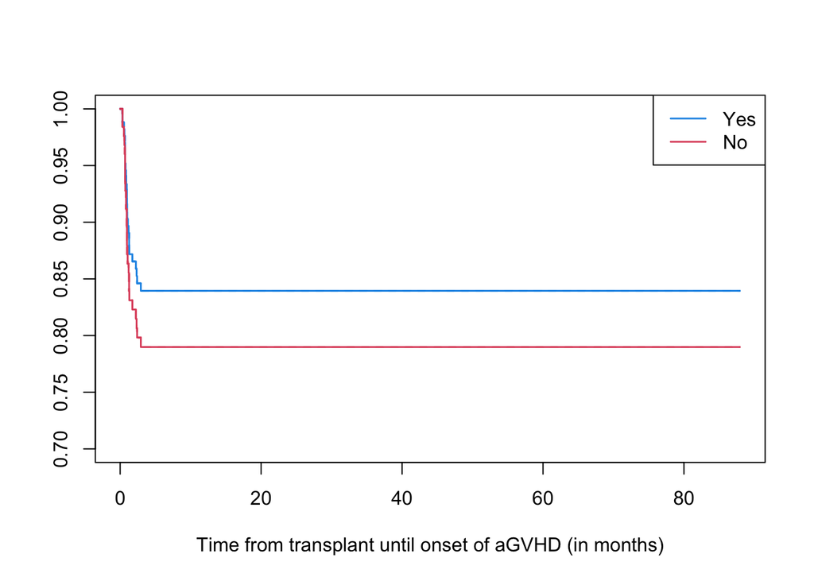

```r
## fix the confounders??
# provide an estimate survival function of time from transplant until onset of aGVHD separately for patient without mtx use, aged 28 (??), negative status and fab=other, and smilar patients with mtx use.
# plot(survfit(model5,newdata=data.frame(mtx="No",age=28,cmv="Negative",fab="Other"),conf.int=FALSE),col=4,xlab="Time from transplant until onset of aGVHD (in months)",ylim=c(0.7,1))
# lines(survfit(model5,newdata=data.frame(mtx="Yes",age=28,cmv="Negative",fab="Other"),conf.int=FALSE),col=2)

model5_unadjust<-coxph(s.data~mtx,data=data)
plot(survfit(model5_unadjust,newdata=data.frame(mtx="Yes"),conf.int=FALSE),col=4,lwd=1.5,
     xlab="Time from transplant until onset of aGVHD (in months)",ylim=c(0.7,1))
lines(survfit(model5_unadjust,newdata=data.frame(mtx="No"),conf.int=FALSE),col=2,lwd=1.5,)
legend("topright",legend=c("Yes","No"),col=c(4,2),lwd=c(1.5,1.5))
```

**Note: I am not sure the approach for 2 is corect. I plotted KM Curve for two methotrexate use group, without fixing the confounders. If we do need to fix the confounder (see the codee I commented down, OR Chapter 3 slides, page 99-104), the sample size of each subgroup will be really small, which may not provide an accurate summary. Which approach do you think it is more proper?**

Result: From the stratified ph model, there is no evidence for association between aGVHD occurrenc and mtx use.

**7. Based on the available data, is recovery of normal platelet levels associated with improved disease- free survival? Is it associated with a decreased risk of relapse?**

```r
# Similar to Q4
## include time-varying covariate derived from deltap
data.tvc<-tmerge(data1=data,
                   data2=data,
                   id=id,
                   deltadfs=event(tdfs,deltadfs),
                   deltar=event(tdfs,deltar),
                   postP=tdc(tp))
head(data.tvc)
```

|  | id | ts | deltas | tdfs | deltar | deltadfs | ta | deltaa | tp | deltap | disgroup | age | male | cmv | donorage | donormale | donorcmv | waittime | fab | hospital | mtx | tstart | tstop | postP |
| --- | --- | --- | --- | --- | --- | --- | --- | --- | --- | --- | --- | --- | --- | --- | --- | --- | --- | --- | --- | --- | --- | --- | --- | --- |
| 1 | 1 | 2081 | 0 | 2081 | 0 | 0 | 67 | 1 | 13 | 1 | ALL | 26 | Male | Positive | 33 | Female | Positive | 98 | Other | 1 | No | 0 | 13 | 0 |
| 2 | 1 | 2081 | 0 | 2081 | 0 | 0 | 67 | 1 | 13 | 1 | ALL | 26 | Male | Positive | 33 | Female | Positive | 98 | Other | 1 | No | 13 | 2081 | 1 |
| 3 | 2 | 1602 | 0 | 1602 | 0 | 0 | 1602 | 0 | 18 | 1 | ALL | 21 | Male | Negative | 37 | Male | Negative | 1720 | Other | 1 | No | 0 | 18 | 0 |
| 4 | 2 | 1602 | 0 | 1602 | 0 | 0 | 1602 | 0 | 18 | 1 | ALL | 21 | Male | Negative | 37 | Male | Negative | 1720 | Other | 1 | No | 18 | 1602 | 1 |
| 5 | 3 | 1496 | 0 | 1496 | 0 | 0 | 1496 | 0 | 12 | 1 | ALL | 26 | Male | Positive | 35 | Male | Negative | 127 | Other | 1 | No | 0 | 12 | 0 |
| 6 | 3 | 1496 | 0 | 1496 | 0 | 0 | 1496 | 0 | 12 | 1 | ALL | 26 | Male | Positive | 35 | Male | Negative | 127 | Other | 1 | No | 12 | 1496 | 1 |

```r
s.data.dfs<-with(data.tvc,Surv(tstart,tstop,deltadfs))
s.data.r<-with(data.tvc,Surv(tstart,tstop,deltar))

#aGVHD occurrence and disease free survival
coxph(s.data.dfs~postP+fab,data=data.tvc)
```

```
## Call:
## coxph(formula = s.data.dfs ~ postP + fab, data = data.tvc)
##
##             coef exp(coef) se(coef)      z        p
## postP    -1.2269    0.2932   0.3282 -3.739 0.000185
## fabOther -0.6046    0.5463   0.2239 -2.701 0.006918
##
## Likelihood ratio test=18.88  on 2 df, p=7.929e-05
## n= 256, number of events= 83
```

```r
#aGVHD occurrence and relapse
coxph(s.data.r~postP+fab,data=data.tvc)
```

```
## Call:
## coxph(formula = s.data.r ~ postP + fab, data = data.tvc)
##
##             coef exp(coef) se(coef)      z        p
## postP    -0.1964    0.8217   0.6188 -0.317 0.750900
## fabOther -1.0402    0.3534   0.3103 -3.352 0.000801
##
## Likelihood ratio test=11.14  on 2 df, p=0.003802
## n= 256, number of events= 42
```

To examine the association between recovery of normal platelet levels and improved disease-free survival or decreased risk of relapse, we fit a proportional hazard model with a time-varying predictor, recovery of normal platelet levels. We considered recovery status of normal platelet levels, Recovery(t), as 1 if recovery occurred by time t, as 0 if recovery had not occurred by time t. We treated patients who experienced recovery of normal platelet levels as two different pseudo-patients before and after recovery since the hazard rate may change due to recovery occurrence. For pre-recovery occurence patients, the start time was considered as 0 and the stop time as time until recovery occurred. For post-recovery patients, the start time was considered as time until recovery occurred, the stop time as time until relapse, death or end of the study. Using the adjusted dataset with pseudo-patients, a proportional hazard model was fit with recovery of normal platelet levels as the predictor of interest, indicator of disease-free survival as the outcome of interest, and start time to stop time as follow-up time interval, including FAB classification as the confounder.. A logrank test was conducted to test the null hypothesis that there is no association between recovery of normal platelet levels and disease-free survival. Another proportional hazard model was fitted with recovery of normal platelet levels as the predictor of interest, indicator of relapse as the outcome of interest, start time to stop time as follow-up time interval, including FAB classification as the confounder. A logrank test was conducted to test the null hypothesis that there is no association between recovery of normal platelet levels and risk of relapse.

Result: there is strong evidence for the association between recovery of normal platelet levels and improved disease-free survival. No evidence for association between recovery of normal platelet levels and decreased risk of relapse.